# CEE218X Assignment 4

## 4

*Consider the datasets that are publicly available to us for observing outcomes in the Bay Area over time (such as 5-yr and 1-yr ACS and PUMS data, PG&E energy data, air quality data, etc.), with all of their various limitations, and explore one question of interest using a difference-in-difference analysis. This brainstorming should be guided by some open-ended searching for research papers online, as well as searching for notable events in the Bay Area (within the time period for which we have data) that had a focused geographic effect that may be observable through our longitudinal data.*

### The Impact of Apple Park on Cupertino

Let’s consider the impact of **the opening of Apple Park** in April 2017 on the surrounding neighborhoods in Cupertino.

- According to [the Verge](https://www.theverge.com/2017/2/22/14696808/apple-park-campus-steve-jobs-theater-april-2017), 12,000 employees at Apple will move into this new 175-acre complex. Considering the overall high-tier income in the tech industry, especially big monopolies like Apple, we might expect the neighborhoods around Apple Park sees an increasing number of high-income households.
- If we can gather longitudinal information about the total number of households with more than 100k annual income before and after the “treatment” of a newly opened Apple Park, a granularity that allows us to meaningfully isolate the populations likely to be affected by the treatment, then a differences-in-differences analysis would be expected to show an increase in the total number of households with more than 100k annual income relative to similar populations in the Bay Area that did not experience such change brought by Apple Park.

Now let’s run some experiments:

```r
library(tigris)
library(tidyverse)
library(tidycensus)
library(sf)
library(leaflet)
library(StatMatch)
library(censusapi)
library(kableExtra)
library(plotly)
census_api_key("c8aa67e4086b4b5ce3a8717f59faa9a28f611dab")
Sys.setenv(CENSUS_KEY="c8aa67e4086b4b5ce3a8717f59faa9a28f611dab")

census_api_key("c8aa67e4086b4b5ce3a8717f59faa9a28f611dab")

bay_county_names <-
  c(
    "Alameda",
    "Contra Costa",
    "Marin",
    "Napa",
    "San Francisco",
    "San Mateo",
    "Santa Clara",
    "Solano",
    "Sonoma"
  )
ca_pumas <-
  pumas("CA", cb = T, progress_bar = F)

bay_county_names <-
  c(
    "Alameda",
    "Contra Costa",
    "Marin",
    "Napa",
    "San Francisco",
    "San Mateo",
    "Santa Clara",
    "Solano",
    "Sonoma"
  )

bay_counties <-
  counties("CA", cb = T, progress_bar = F) %>%
  filter(NAME %in% bay_county_names)

bay_pumas <-
  ca_pumas %>%
  st_centroid() %>%
  .[bay_counties, ] %>%
  st_set_geometry(NULL) %>%
  left_join(ca_pumas %>% select(GEOID10)) %>%
  st_as_sf()
```

```r
leaflet() %>%
  addProviderTiles(providers$CartoDB.Positron) %>%
  addPolygons(
    data = bay_pumas,
    weight = 1,
    color = "gray"
  ) %>%
  addMarkers(
    lng = -122.0055,
    lat = 37.3326
  ) %>%
  addPolygons(
    data = bay_pumas %>%
      filter(PUMACE10 == "08507")
  )
```

[interactive chart not shown]

In the map above, I’ve placed a marker at the location of the Apple Park campus: it lies inside the boundaries of Cupertino County but is actually at the intersection of Cupertino, Sunnyvale and Santa Clara. Given the fact that there are numerous tech companies already located in both Santa Clara and Sunnyvale, while Apple is the single largest employer in Cupertino according to City’s [Comprehensive Annual Financial Report](http://www.cupertino.org/Home/ShowDocument?id=7597). So we will focus our analysis on Cupertino in the following experiments.

```r
pums_income <-
  2015:2017 %>%
  map_dfr(function(year){
    get_pums(
      variables = c(
        "PUMA",
        "SCHL",
        "HINCP"
      ),
      state = "CA",
      year = year,
      survey = "acs1",
      recode = F
    ) %>%
      mutate(
        high_income = ifelse(
          HINCP > 100000,
          WGTP,
          0
        ),
        PUMA = PUMA %>% str_pad(5,"left","0")
      ) %>%
      group_by(PUMA) %>%
      summarize(
        pop = sum(PWGTP),
        high_income = sum(high_income),
        year = year
      )
  })
```

We choose to use 1-year PUMS estimates in order to manage the trade-off between recency and geographic granularity, because PUMA data are sufficiently granular to identify a particular neighborhood where we expect the “treatment” to be experienced. We’ll choose data from 2015 through 2017 so we can match this PUMA to other PUMAs based on similar trends in the two years prior to treatment, and so we can observe the potential impact of the treatment in 2017. As for variables, let’s look at HINCP which is “Household income (past 12 months)”. We’ll calculate the number of households above the annual income of $100k.

```r
pums_pal <- colorNumeric(
  palette = "GnBu",
  domain = pums_income$high_income
)

leaflet() %>%
  addProviderTiles(providers$CartoDB.Positron) %>%
  addPolygons(
    data = pums_income %>%
      right_join(bay_pumas %>% select(PUMA = PUMACE10)) %>%
      st_as_sf(),
    fillColor = ~pums_pal(high_income),
    color = "white",
    weight = 1,
    label = ~paste0(PUMA,": ", high_income, " households with $100K income or higher")
  )
```

[interactive chart not shown]

This map visualizes the number of households with $100K annual income or higher in the bay area. We could see a large number of them are in south bay cities like Palo Alto and Mountain View. Now, let’s further manipulate this data so that, for each PUMA, the different years of available data are in wide format. In addition, we can apply the Mahalanobis matching technique from this section to PUMAs in the Bay Area, using the 2015 and 2016 highincome values:

```r
pums_income_clean <-
  pums_income %>%
  select(-pop) %>%
  pivot_wider(
    names_from = year,
    values_from = high_income
  ) %>%
  filter(PUMA %in% bay_pumas$PUMACE10)
```

```r
obs_matrix <-
  pums_income_clean %>%
  select(`2015`,`2016`) %>%
  as.matrix()

dist_matrix <- mahalanobis.dist(obs_matrix)

rownames(dist_matrix) <- pums_income_clean$PUMA
colnames(dist_matrix) <- pums_income_clean$PUMA

match <- dist_matrix["08507",] %>%
  as.data.frame() %>%
  rownames_to_column() %>%
  rename(
    PUMA = rowname,
    match = "."
  ) %>%
  right_join(
    pums_income_clean
  ) %>%
  arrange(match) %>%
  .[1:11, ] %>%
  left_join(bay_pumas %>% select(PUMA = PUMACE10)) %>%
  st_as_sf()

leaflet() %>%
  addTiles() %>%
  addProviderTiles(providers$CartoDB.Positron) %>%
  addPolygons(
    data = match[1, ],
    color = "red",
    label = ~PUMA
  ) %>%
  addPolygons(
    data = match[-1, ],
    label = ~PUMA
  )
```

[interactive chart not shown]

Here we have a visualization of similar neighborhoods with Cupertino on the number of households with $100k annual income or higher. Now, let’s visually inspect what the longitudinal results look like, comparing our treatment PUMA to the average of the ten matched PUMAs:

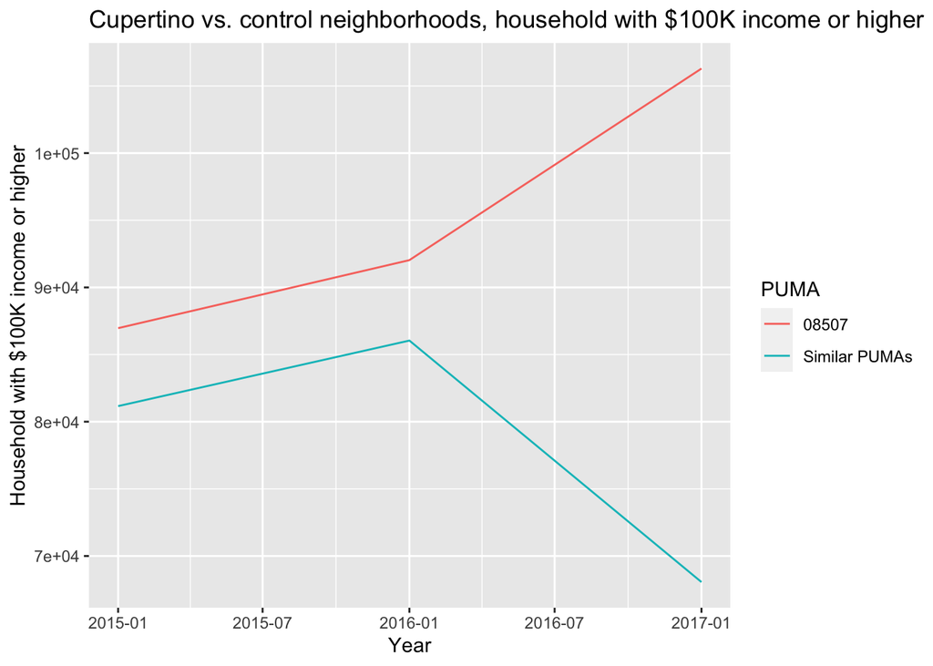

```r
match_pumas <-
  match[-1,] %>%
  st_set_geometry(NULL) %>%
  select(-match) %>%
  pivot_longer(
    -PUMA,
    names_to = "year",
    values_to = "high_income"
  ) %>%
  group_by(
    year
  ) %>%
  summarize(
    high_income = mean(high_income),
    PUMA = "Similar PUMAs"
  )

treatment_puma <-
  match[1,] %>%
  select(-match) %>%
  st_set_geometry(NULL) %>%
  pivot_longer(
    -PUMA,
    names_to = "year",
    values_to = "high_income"
  )

rbind(
  treatment_puma,
  match_pumas
) %>%
  mutate(
    year = year %>% paste0(.,"-01-01") %>%  as.Date()
  ) %>%
  ggplot(
    aes(
      x = year,
      y = high_income,
      color = PUMA
    )
  ) +
  geom_line() +
  geom_vline(xintercept = 2017, linetype = "dashed") +
  labs(
    title = "Cupertino vs. control neighborhoods, household with $100K income or higher",
    x = "Year",
    y = "Household with $100K income or higher"
  )
```

Based on just the graph, it may seem clear that the selected PUMA has an increase in the total number of households with $100k income or higher relative to the control PUMAs in 2017. Given the scale of that difference and the averaging of the behavior of the control PUMAs, let’s see the results of the formal difference-in-differences analysis using linear models:

- We’ll create a tidy version of the data for our treatment and control PUMAs first, to include coded variables time and treated which identify year 2017 and the records pertaining to the Cupertino PUMA.
- To simulate a difference-in-differences regression, we’ll include treated*time on the right side of the linear model, which is an interaction between the treatment unit and the time of treatment.

```r
income_did <-
  match %>%
  st_set_geometry(NULL) %>%
  select(-match) %>%
  pivot_longer(
    -PUMA,
    names_to = "year",
    values_to = "edu"
  ) %>%
  mutate(
    year = year %>% as.numeric(),
    time = ifelse(year == 2017, 1, 0),
    treated = ifelse(PUMA == "08507", 1, 0)
  )

did_reg <- lm(edu ~ treated*time, data = income_did)

summary(did_reg)
```

```
##
## Call:
## lm(formula = edu ~ treated * time, data = income_did)
##
## Residuals:
##    Min     1Q Median     3Q    Max
## -32448  -5048   -589   4948  21538
##
## Coefficients:
##              Estimate Std. Error t value Pr(>|t|)
## (Intercept)     83602       2294  36.438  < 2e-16 ***
## treated          5897       7610   0.775 0.444664
## time           -15542       3974  -3.911 0.000509 ***
## treated:time    32338      13180   2.454 0.020393 *
## ---
## Signif. codes:  0 '***' 0.001 '**' 0.01 '*' 0.05 '.' 0.1 ' ' 1
##
## Residual standard error: 10260 on 29 degrees of freedom
## Multiple R-squared:  0.4558, Adjusted R-squared:  0.3995
## F-statistic: 8.095 on 3 and 29 DF,  p-value: 0.0004553
```

Here’s the summary from the regression analysis：

- The coefficient of treated:time is the “difference-in-differences” result of interest, it appears to be statistically significant since p-value is less than 5%), as we describe the treatment as the opening of new Apple Park campus in 2017. It has an estimated impact of about 30k new households according to the regression analysis. It seems the completion of Apple Park stimulate a significant number of high-income households moving into Cupertino area.
- From the above difference-in-differences plot, we find neighborhoods similar to Curpertino on the number of households with $100k annual income or higher seem to have an overall trend of outflow of high-income households after 2016. This could be results from high real-estate price in the bay area.
- We choose the number of households with $100k annual income or higher as a particular outcome to observe and evaluate, however, this could just be one of many impacts brought by the completion and opening of Apple Park. For example, we might also expect changes in aspects like the number of tourists and immigrants.
- In this experiment we did not match based on any other variables other than 2015 and 2016 number of households with more than 100k annual income. In future works, we could controlled for other variables like employment, income, demographics.